# Toy examples: Partitions of 2D velocity fields

This is an R Markdown document to illustrate the basic operations of random partitions on velocity fields. The goal is it to evaluate Bayes factors for different example fields.

## First example: One rotation

In this exmaple we simulate a case where spliting the partitions has a lower probabilty, thus the Bayes factor is above 1.

### Create transformation matrices

```r
# Dimension of velocity field
dimension = 2

# Rotation matrix
R = diag(dimension + 1)
angle = pi/10
R[1, 1] = cos(angle)
R[1, 2] = -sin(angle)
R[2, 1] = sin(angle)
R[2, 2] = cos(angle)
```

### Create and visualize velocity fields

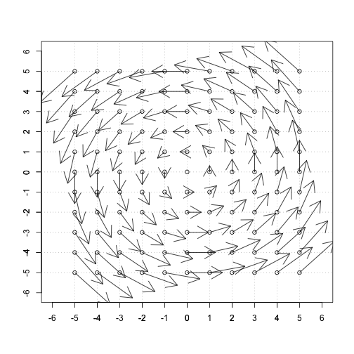

```r
# Load library
library(expm, quietly = TRUE)
source("HelperFunctions.R")

# Create the grid
size = 5
createEmptyGrid(size)

noOfVoxels = length(-size:size)^2
V = matrix(0, dimension, noOfVoxels)
X = matrix(0, dimension + 1, noOfVoxels)

# Generate fields
currentIndex = 1
for (i in -size:size) {
    for (j in -size:size) {
        X[, currentIndex] = c(i, j, 1)
        currentIndex = currentIndex + 1
    }
}
V = logm(R)[1:2, ] %*% X

# Visualize fields
visualizeVelField(V, X, "black")
```

### Split velocity field in half

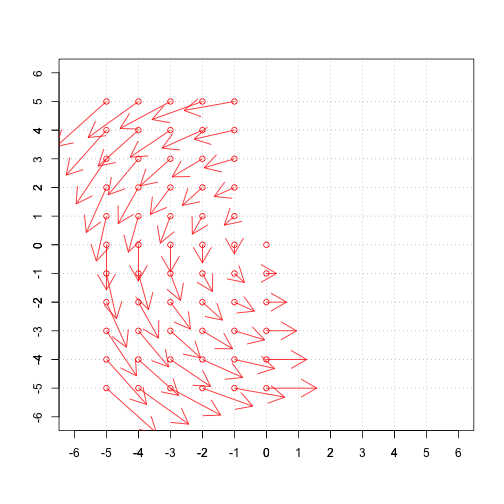

```r
# First partition
V1 = V[, 1:61]
X1 = X[, 1:61]
plot.new()
createEmptyGrid(size)
visualizeVelField(V = V1, X = X1, color = "red")
```

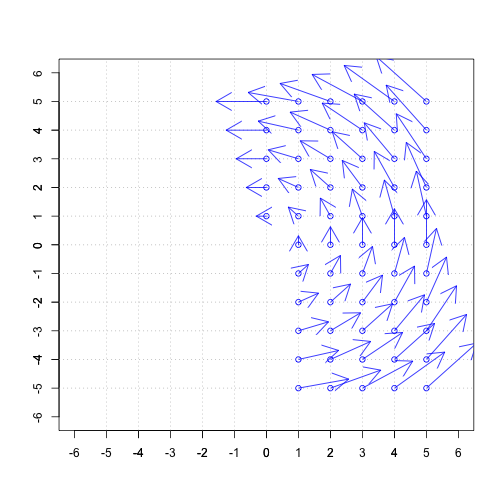

```r
# Second partition
V2 = V[, 62:121]
X2 = X[, 62:121]
plot.new()
createEmptyGrid(size)
visualizeVelField(V = V2, X = X2, color = "blue")
```

### Bayes factor with fixed \( \sigma_v^2 \)

#### Marginal likelihood

Equation from [our GSI 2013 paper](http://stanford.edu/%7Ecseiler/publications.html):

\[ p(\boldsymbol{v} | \mu,\Gamma,\sigma_{v}^{2}) = \int p(\boldsymbol{v}|\Phi \boldsymbol{m},\sigma_{v}^{2}) p(\boldsymbol{m}|\mu,\Gamma) d\boldsymbol{m} = \frac{|\sigma_v^2 \Gamma|^{1/2}}{(2\pi \sigma_v^2)^{dN/2} |\sigma_v^2 \check{\Gamma}|^{1/2}} \exp \left( \frac{1}{2 \sigma_{v}^{2} } \boldsymbol{v}^t\Phi (\sigma_v^2 \check{\Gamma})^{-1} \Phi^t \boldsymbol{v} \right) \] where \( \check{\Gamma} \) is the posterior concentration matrix: \[ \check{\Gamma} = \frac{1}{\sigma_v^2} \Phi^t \Phi + \Gamma \]

#### Hyperparameters

To compare with fixed multivariate normal noise \( \Sigma \) (next section), we introduce a columnwise parameterize of the concentration matrix:

\[ K \otimes I_d = \sigma_v^2 \Gamma \]

```r
variance = 1e-05
B = diag(c(100, 100, 1))
Gamma = B %x% diag(1, dimension)
```

#### Ratio of marginal likelihoods

```r
computeMarginalLikelihoodFixedLowercaseSigma <- function(V, X, Gamma, variance) {
    d = dim(V)[1]
    N = dim(V)[2]
    X[1:d, ] = t(scale(t(X[1:d, ]), center = TRUE, scale = FALSE))

    Phi = matrix(0, 0, d * (d + 1))
    for (i in 1:N) {
        Phi = rbind(Phi, t(X[, i]) %x% diag(1, 2))
    }

    GammaCheck = 1/variance * t(Phi) %*% Phi + Gamma
    normalizingConstant = 1/2 * log(det(variance * Gamma)) - d * N/2 * log(2 *
        pi * variance) - 1/2 * log(det(variance * GammaCheck))
    marginalLikeihood = normalizingConstant + 1/(2 * variance) * t(c(V)) %*%
        Phi %*% solve(variance * GammaCheck) %*% t(Phi) %*% c(V)

    return(marginalLikeihood)
}
```

```r
# Bayes factor
logBayesRatio = computeMarginalLikelihoodFixedLowercaseSigma(V, X, Gamma, variance) -
    computeMarginalLikelihoodFixedLowercaseSigma(V1, X1, Gamma, variance) -
    computeMarginalLikelihoodFixedLowercaseSigma(V2, X2, Gamma, variance)
logBayesRatio
```

```
##      [,1]
## [1,]   48
```

```r
exp(logBayesRatio)
```

```
##           [,1]
## [1,] 7.008e+20
```

### Bayes factor with fixed \( \Sigma \)

#### Marginal likelihood

With fixed/known velocity noise, equation from [E. Fox, PhD thesis 2009, page 253 (F.10)](http://www.stat.washington.edu/%7Eebfox/papers.html):

\[ p(V|\Sigma) = \frac{|K|^{d/2}}{|2\pi\Sigma|^{N/2}|S_{XX}|^{d/2}} \exp \left( \frac{1}{2}\operatorname{Trace}(\Sigma^{-1} VX^t S_{XX}^{-1} XV^t) \right) \] with \[ S_{XX} = XX^t + K \]

#### Hyperparameters

```r
Sigma = variance * diag(1, dimension, dimension)
K = variance * B
```

#### Ratio of marginal likelihoods

```r
computeMarginalLikelihoodFixedUppercaseSigma <- function(V, X, K, Sigma) {
    d = dim(V)[1]
    N = dim(V)[2]
    X[1:d, ] = t(scale(t(X[1:d, ]), center = TRUE, scale = FALSE))

    Sxx = X %*% t(X) + K
    normalizingConstant = d/2 * log(det(K)) - N/2 * log(det(2 * pi * Sigma)) -
        d/2 * log(det(Sxx))
    marginalLikeihood = normalizingConstant + 1/2 * sum(diag(solve(Sigma) %*%
        V %*% t(X) %*% solve(Sxx) %*% X %*% t(V)))

    return(marginalLikeihood)
}
```

```r
# Bayes factor
logBayesRatio = computeMarginalLikelihoodFixedUppercaseSigma(V, X, K, Sigma) -
    computeMarginalLikelihoodFixedUppercaseSigma(V1, X1, K, Sigma) - computeMarginalLikelihoodFixedUppercaseSigma(V2,
    X2, K, Sigma)
logBayesRatio
```

```
## [1] 48
```

```r
exp(logBayesRatio)
```

```
## [1] 7.008e+20
```

### Bayes factor with random \( \Sigma \)

#### Hyperparameters

```r
n0 = 4
S0 = diag(1, dimension, dimension)
S0 = variance * S0
```

#### Marginal likelihood

Equation from [Ghosh et al., NIPS 2012](http://cs.brown.edu/%7Esghosh/):

\[ p(V|X,K,n_0,S_0) = \frac{ |K|^{d/2} |S_0|^{n_0/2} \Gamma_3 \left( \frac{N+n_0}{2} \right) }{ \pi^{dN/2} |S_{XX}|^{d/2} |S_0 + S_{V|X}|^{(N+n_0)/2} \Gamma_3 \left( \frac{n_0}{2} \right) } \]

#### Ratio of marginal likelihoods

```r
computeMarginalLikelihoodRandomSigma <- function(V, X, K, n0, S0) {
    d = dim(V)[1]
    N = dim(V)[2]

    X[1:d, ] = t(scale(t(X[1:d, ]), center = TRUE, scale = FALSE))

    Sxx = X %*% t(X) + K
    Svx = V %*% t(V) - V %*% t(X) %*% solve(Sxx) %*% X %*% t(V)
    marginalLikeihood = 0.5 * d * log(det(K)) + 0.5 * n0 * log(det(S0)) + lgamma2(0.5 *
        N + 0.5 * n0) - 0.5 * d * N * log(pi) - 0.5 * d * log(det(Sxx)) - (0.5 *
        N + 0.5 * n0) * log(det(S0 + Svx)) - lgamma2(0.5 * n0)

    return(marginalLikeihood)
}
```

```r
# Bayes factor
logBayesRatio = computeMarginalLikelihoodRandomSigma(V, X, K, n0, S0) - computeMarginalLikelihoodRandomSigma(V1,
    X1, K, n0, S0) - computeMarginalLikelihoodRandomSigma(V2, X2, K, n0, S0)
logBayesRatio
```

```
## [1] 126.2
```

```r
exp(logBayesRatio)
```

```
## [1] 6.581e+54
```

## Second example: Two rotations

In this exmaple we simulate a case where joining the partitions has a lower probabilty, thus the Bayes factor is below 1.

```r
# Two translation matrices
T1 = diag(dimension + 1)
T1[1, 3] = -3
T1[2, 3] = 0

T2 = diag(dimension + 1)
T2[1, 3] = 3
T2[2, 3] = 0

# Two rotation matrices
R1 = diag(dimension + 1)
angle1 = pi/10
R1[1, 1] = cos(angle1)
R1[1, 2] = -sin(angle1)
R1[2, 1] = sin(angle1)
R1[2, 2] = cos(angle1)

R2 = solve(R1)

# Composition of transformations
A1 = T1 %*% R1 %*% solve(T1)
A2 = T2 %*% R2 %*% solve(T2)

# Two new velocity fields
V1 = logm(A1)[1:2, ] %*% X1
V2 = logm(A2)[1:2, ] %*% X2
V = cbind(V1, V2)

# Visualize velocity fields and compute Bayes factors
bayesFactors = computeBayesFactors(V, V1, V2, X, X1, X2, Gamma, variance, K,
    Sigma, n0, S0)
```

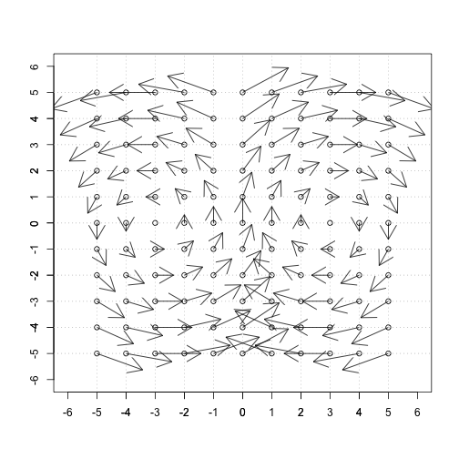

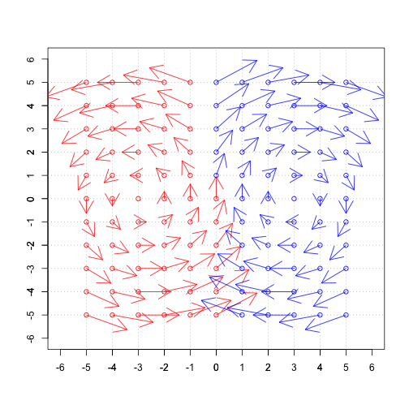

```r
bayesFactors
```

```
## bfFixedLowercaseSigma      bfUppercaseSigma         bfRandomSigma
##                     0                     0                     0
```

## Third example: Anisotropic scaling

### One scaling transformation

```r
# Scaling matrix
S = diag(c(1.2, 0.8, 1))

# Velocity field
V = logm(S)[1:2, ] %*% X

# Split velocity field in half
V1 = V[, 1:61]
V2 = V[, 62:121]

# Visualize velocity fields and compute Bayes factors
bayesFactors = computeBayesFactors(V, V1, V2, X, X1, X2, Gamma, variance, K,
    Sigma, n0, S0)
```

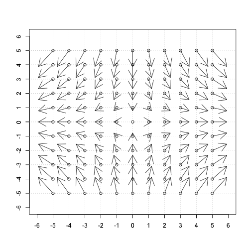

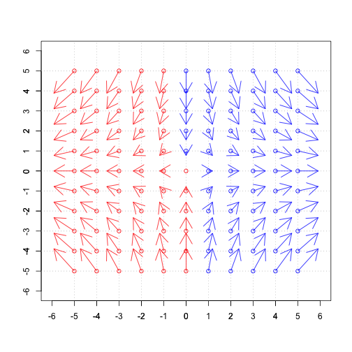

```r
bayesFactors
```

```
## bfFixedLowercaseSigma      bfUppercaseSigma         bfRandomSigma
##             1.411e+18             1.411e+18             1.676e+53
```

### Two scaling transformations

```r
# Composition of transformations
A1 = T1 %*% S %*% solve(T1)
A2 = T2 %*% S %*% solve(T2)

# Two new velocity fields
V1 = logm(A1)[1:2, ] %*% X1
V2 = logm(A2)[1:2, ] %*% X2
V = cbind(V1, V2)

# Visualize velocity fields and compute Bayes factors
bayesFactors = computeBayesFactors(V, V1, V2, X, X1, X2, Gamma, variance, K,
    Sigma, n0, S0)
```

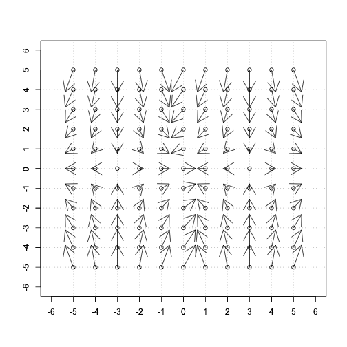

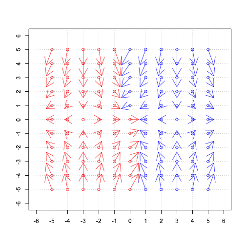

```r
bayesFactors
```

```
## bfFixedLowercaseSigma      bfUppercaseSigma         bfRandomSigma
##             0.000e+00             0.000e+00            1.376e-281
```

## Fourth example: Translation

### One translation

```r
# Translation matrix
C = diag(c(1, 1, 1))
C[1, 3] = 0.5
C[2, 3] = 0.5

# Velocity field
V = logm(C)[1:2, ] %*% X

# Split velocity field in half
V1 = V[, 1:61]
V2 = V[, 62:121]

# Visualize velocity fields and compute Bayes factors
bayesFactors = computeBayesFactors(V, V1, V2, X, X1, X2, Gamma, variance, K,
    Sigma, n0, S0)
```

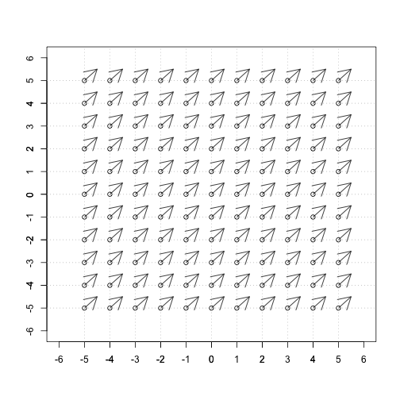

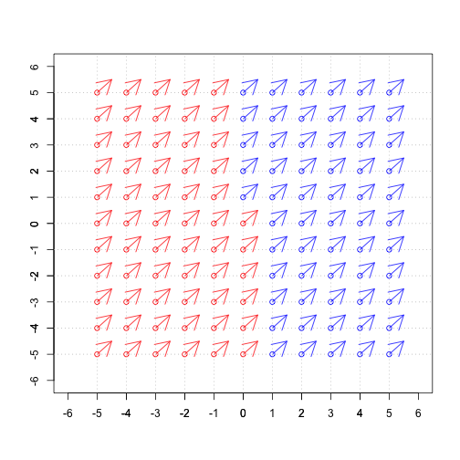

```r
bayesFactors
```

```
## bfFixedLowercaseSigma      bfUppercaseSigma         bfRandomSigma
##             2.220e+16             2.220e+16             1.515e+49
```

### Two translations

```r
# Composition of transformations
A1 = T1 %*% C %*% solve(T1)
A2 = T2 %*% solve(C) %*% solve(T2)

# Two new velocity fields
V1 = logm(A1)[1:2, ] %*% X1
V2 = logm(A2)[1:2, ] %*% X2
V = cbind(V1, V2)

# Visualize velocity fields and compute Bayes factors
bayesFactors = computeBayesFactors(V, V1, V2, X, X1, X2, Gamma, variance, K,
    Sigma, n0, S0)
```

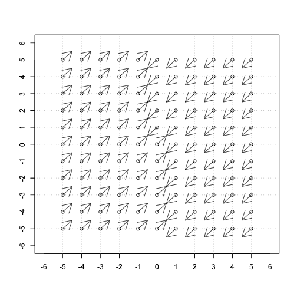

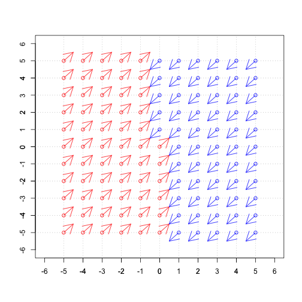

```r
bayesFactors
```

```
## bfFixedLowercaseSigma      bfUppercaseSigma         bfRandomSigma
##                     0                     0                     0
```

## Fifth example: Adding i.i.d. normal noise

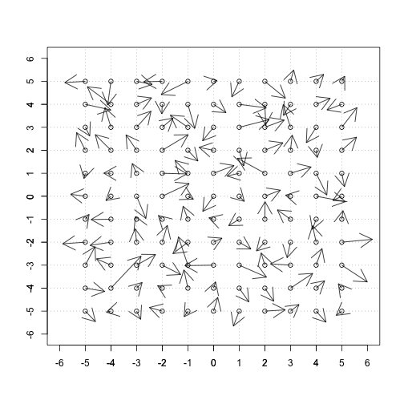

```r
# Load library
library(MASS, quietly = TRUE)

# define hyperparameter
variance = 0.1
B = diag(c(100, 100, 1))
Gamma = B %x% diag(1, dimension)

Sigma = variance * diag(1, dimension, dimension)
K = variance * B

n0 = 4
S0 = diag(1, dimension, dimension)
S0 = variance * S0

# i.i.d. normal noise velocity field
noise = mvrnorm(dimension, rep(0, dim(V)[2]), sqrt(variance) * diag(1, dim(V)[2]))
plot.new()
createEmptyGrid(size)
visualizeVelField(noise, X, color = "black")
```

### One rotation

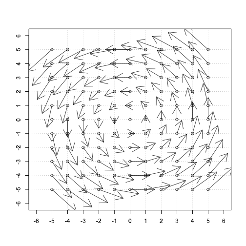

```r
# Show noise free field for comparison
V = logm(R)[1:2, ] %*% X
plot.new()
createEmptyGrid(size)
visualizeVelField(V, X, color = "black")
```

```r
# Add noise
V = V + noise
V1 = V[, 1:61]
V2 = V[, 62:121]

# Visualize velocity fields and compute Bayes factors
bayesFactors = computeBayesFactors(V, V1, V2, X, X1, X2, Gamma, variance, K,
    Sigma, n0, S0)
```

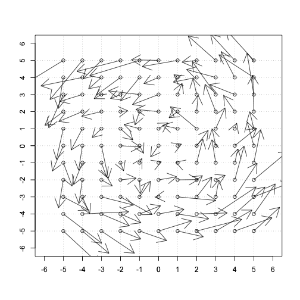

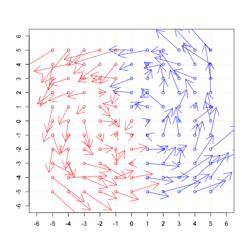

```r
bayesFactors
```

```
## bfFixedLowercaseSigma      bfUppercaseSigma         bfRandomSigma
##                454280                454280             645802843
```

### Two rotations

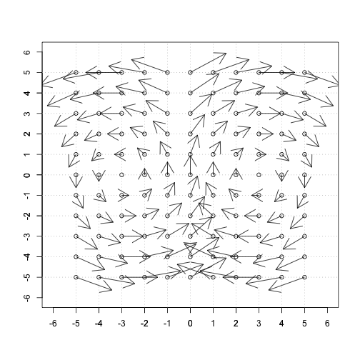

```r
# Show noise free field for comparison
A1 = T1 %*% R1 %*% solve(T1)
A2 = T2 %*% R2 %*% solve(T2)
V1 = logm(A1)[1:2, ] %*% X1
V2 = logm(A2)[1:2, ] %*% X2
V = cbind(V1, V2)
plot.new()
createEmptyGrid(size)
visualizeVelField(V, X, color = "black")
```

```r
# Add noise
V = V + noise
V1 = V[, 1:61]
V2 = V[, 62:121]

# Visualize velocity fields and compute Bayes factors
bayesFactors = computeBayesFactors(V, V1, V2, X, X1, X2, Gamma, variance, K,
    Sigma, n0, S0)
```

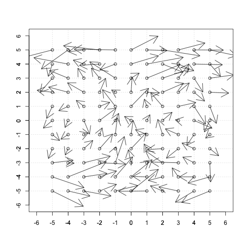

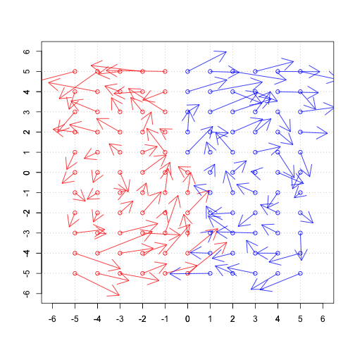

```r
bayesFactors
```

```
## bfFixedLowercaseSigma      bfUppercaseSigma         bfRandomSigma
##            3.030e-312            3.030e-312             1.283e-46
```